# Laboration 2

Förnamn Efternamn

2024-12-13

# Uppgift 1

Eftersom datan är parvist beroende skulle det vara trevligt att ha ett nytt stickprov som bara består av differansen mellan paren av dagar. Dessa nya datapunkter som består av differansen kommer då att vara sinsemellan obereonde. Vad vi är intresserade av är ju om det finns en skillnad i medelvärde mellan de två stickproven. Det vill säga, vår nollhypotes blir $H_0 : \mu_0 = \mu_{nonseed} - \mu_{seed} = 0$, och vår alternativa hypotes, $H_1 : \mu_0 \ne 0$.

Vi är nu redo att avläsa datan vi har till hand, och vi gör detta enligt instruktionerna, men vi passar även på att skapa en differans-vektor som består av skillnaden i nederbörd mellan dagarna i varsin tvådagarsperiod.

Vi börjar med att undersöka om båda stickproven följer samma fördelning, och isåfall, vilken. Vi anar att histogramen kommer duga för detta, så vi plottar de sida vid sida (tillsammans hjälps de åt).

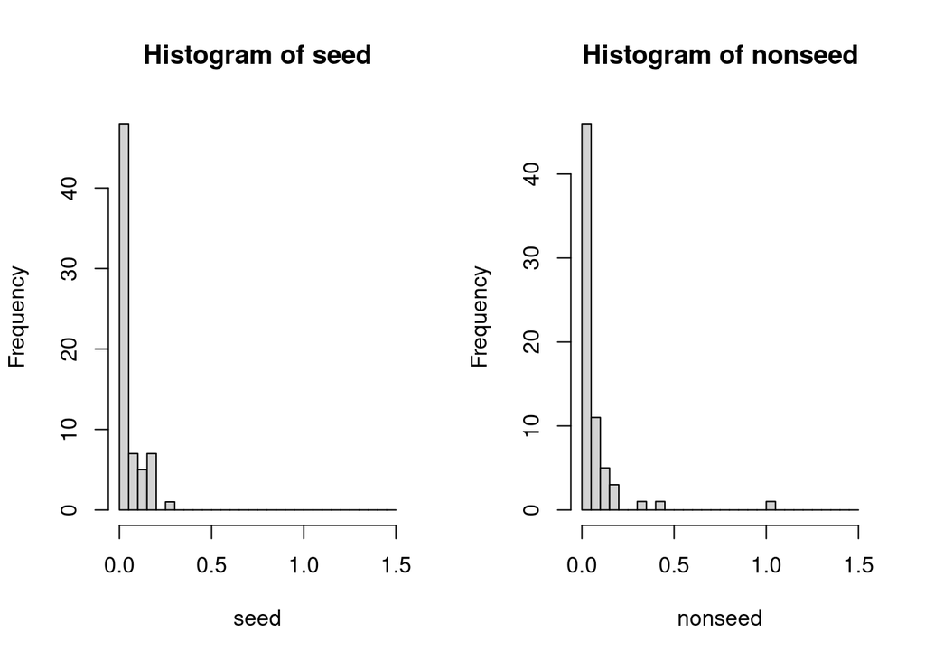

```r
old_par <-par(mfrow = c(1,2))
hist(seed, breaks = seq(from = 0, to = 1.5, by = 0.05))

hist(nonseed, breaks = seq(from = 0, to = 1.5, by = 0.05))
```

I figur 1 avläser vi rätt säkert att datan, oberoende av om molnsådd genomförs eller inte, är grovt exponentialfördelat. Detta är inte så konstigt, iom att de flesta dagarna regnar det inte i Arizona, molnströssel eller ej. Det råder nu att undersöka vilken fördelning differansen av nederbörd mellan dagarna i tvådagarsperioder har. Egentligen är vi bara intresserade av om fördelningen är normal eller inte, eftersom det kommer att avgöra vilket typ av test som är mest lämpligt. Detta undersöker vi med hjälp av histogram, men vi slänger även in en normalfördelningsplott för säkerhetens skull.

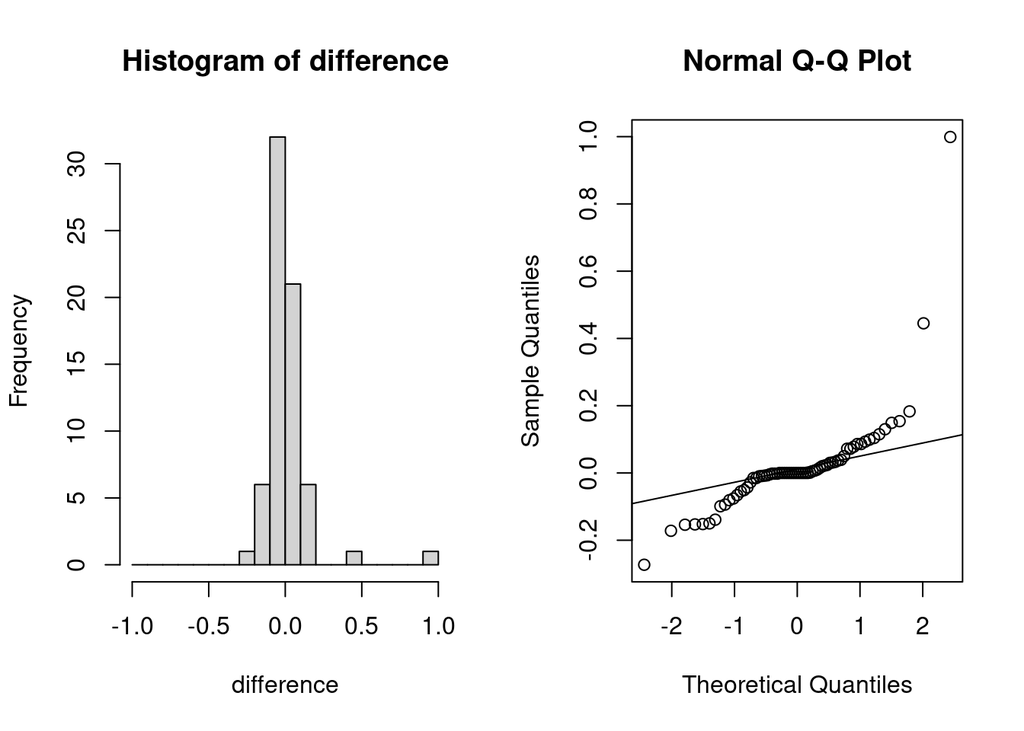

```r
old_par <-par(mfrow = c(1,2))

hist(difference, breaks = seq(from = -1, to = 1, by = 0.1))

qqnorm(difference)
qqline(difference)
```

```r
#boxplot(difference)
```

Eftersom differansen mellan tvådagarsperioderna är oberoende, och fördelningen behåller en viss symmetri mellan dagarna (en differans ligger långt ut till höger men det är acceptabelt), så tror vi att vägen framåt här är att utföra ett Wilcoxon teckenrang test där vi testar om medianen av fördelningen differansen har ligger på talet $0$. Alternativa hypotesen blir då att detta ej är fallet, och vi testar detta med en konfidensgrad av $95%$. För att utföra testet använder vi oss av `R`s inbyggda funktion `wilcox.test()`.

```r
wilcox.test(difference,
            alternative = c("two.sided"),
            mu = 0,
            conf.int = TRUE,
            conf.level = 0.95)
```

```
##
##  Wilcoxon signed rank test with continuity correction
##
## data:  difference
## V = 849, p-value = 0.5107
## alternative hypothesis: true location is not equal to 0
## 95 percent confidence interval:
##  -0.01654121  0.03498019
## sample estimates:
## (pseudo)median
##    0.008020371
```

Eftersom vårat $p_{obs} = 0.5107> 0.05$, kan vi inte förkasta nollhypotesen.

## Uppgift 2.1

1. Det är alltid bra att använda sig av slump när man kan, hade meteorologen fått bestämma när försöket skulle genomföras, hade det kunnat ske något typ av bias om hen vore t.ex. investerad i att se experminentet skulle gå bra/dåligt till. Det hade kunnat vara så att meteorologen hade beslutit om att genomföra molnsådd på dagar då det var extra mycket/lite moln, utav dagarna med rätt förutsättningar, och det hade förmodligen skapat en systematiska fel för experimentet i stort.
2. Vi vill ju undersöka följande frågor: 1. Hade stora och små områden en ökning i nederbörd när man genomförde molnsådd? Och 2. Var effekten större eller mindre för små eller stora områden? Dvs, blev genomsnittliga skillnaden i nederbörd mellan stora och små områden stor eller liten?

Vi har skäl att anta att nederbörden ser olika ut beroende på vilket typ av området vi undersöker, därför kan det vara fördelaktigt att inte slå ihop datan så att vi kan betrakta den enskilt, och göra testet där variansen antas vara lika (men okänd).